# Graphing Data with matplotlib

We will extract data series to plot from pandas DataFrames but, first, let's do a very simple example of a matplotlib line chart and scatterplot.

The statement below causes the matplotlib graphs to appear within the Jupter notebook rather than in a separate window that pops up. This can be very convenient because, among other reasons, the image will be retained in the notebook and computation will not be paused when many graphs are constructed within a loop. Statements that start with '%' are called magic functions. I think it is also fair to say that these are system-level commands that you might type in a DOS Command Window. The '%' indicates a system command so that it is executed properly. This web page talks about magis functions: https://stackoverflow.com/questions/20961287/what-is-pylab

```python
%matplotlib inline
```

The next statement imports the graphing package we will use and uses a very popular, if not ubiquitous alias, plt, for this matplotlib package.

```python
import matplotlib.pyplot as plt
```

## Simple Examples First: Line and Scatterplot

The contents of matplotlib_eg_line.py are contained in the cell below. The plt.show() command is required if you are working in Spyder, but not if you are working in Jupyter and have executed this command: %matplotlib inline

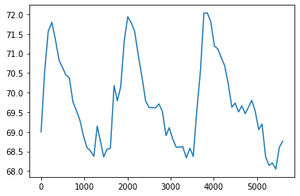

```python
xs = [0,82.0442626658045,164.140532825633,249.101916493353,332.182520454561,416.254670963008,495.330844802651,575.152803567278,653.205144040749,738.002602107511,818.027625347191,898.118246791891,980.079475188722,1061.14169245002,1139.27372549306,1222.46124841828,1300.35875796241,1375.56916894815,1450.58381247379,1528.61926864683,1605.58397275636,1690.73526419816,1765.8607155748,1844.76374052086,1927.68455634244,2007.86892722346,2086.83606915306,2166.71913598734,2251.80135023691,2335.70816516882,2420.79263834332,2499.86354911873,2577.05890165442,2654.19208140119,2730.09283946298,2809.07577275313,2894.08624312766,2969.05670691318,3049.93958564477,3129.75861740531,3206.68277248806,3283.60346903165,3364.58552562287,3449.40362446521,3525.4406380069,3608.13685182861,3690.05929028829,3773.14656467608,3850.22786804579,3930.30737684189,4015.46434790825,4093.50879464788,4172.64841837878,4252.66450124259,4335.57956650011,4420.52164467734,4495.52991250898,4575.39742270308,4650.49642074232,4730.52574677055,4805.68851119975,4880.60019974235,4960.70865715944,5043.67168991259,5118.73724644963,5203.54753389807,5283.38430140739,5359.51383129058,5438.3504224767,5519.19106748314,5597.38879699402]
ys = [69,70.5331166725557,71.5580608629997,71.7925736363559,71.3468902075964,70.8280365103217,70.6414982437025,70.4451053764375,70.3795952412711,69.7645648576213,69.5426154537094,69.3004779067882,68.9026747371149,68.599154906399,68.519069857217,68.3772433121902,69.1486631584102,68.7548264957532,68.3609585242701,68.5575021969504,68.5786288310157,70.1801398605569,69.7914710297875,70.1491959166127,71.3308639026079,71.9361568322099,71.7841530239482,71.5632100706621,70.9532872882161,70.4120650812618,69.7956890967353,69.6193830861858,69.6154149236862,69.6130427165012,69.7102463368457,69.5264209638887,68.9050613087613,69.1051712486311,68.8193037564598,68.6066819000086,68.6092749335593,68.6204785117934,68.3360360051156,68.5812312774717,68.3713770000006,69.5440095449469,70.5260768620176,72.0285425812187,72.0349254824144,71.8158332177273,71.1892654017154,71.1169346409977,70.8948191898231,70.6895661675202,70.2298913978404,69.6255849641529,69.7340391269025,69.5070018796742,69.6617353391113,69.4627544694931,69.630774569752,69.8026157834872,69.5269217792645,69.0549816241028,69.1984712324886,68.3562401007611,68.1422906748129,68.2062726166005,68.0498033914326,68.6018257745021,68.7606159741864]

plt.plot(xs,ys)
plt.show()
```

The contents of matplotlib_eg_scatter.py are contained in the cell below.

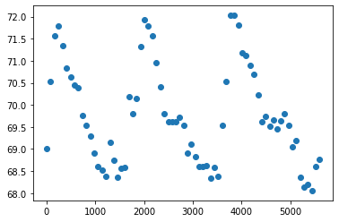

```python
import matplotlib.pyplot as plt

xs = [0,82.0442626658045,164.140532825633,249.101916493353,332.182520454561,416.254670963008,495.330844802651, \
      575.152803567278,653.205144040749,738.002602107511,818.027625347191,898.118246791891,980.079475188722, \
      1061.14169245002,1139.27372549306,1222.46124841828,1300.35875796241,1375.56916894815,1450.58381247379, \
      1528.61926864683,1605.58397275636,1690.73526419816,1765.8607155748,1844.76374052086,1927.68455634244, \
      2007.86892722346,2086.83606915306,2166.71913598734,2251.80135023691,2335.70816516882,2420.79263834332, \
      2499.86354911873,2577.05890165442,2654.19208140119,2730.09283946298,2809.07577275313,2894.08624312766, \
      2969.05670691318,3049.93958564477,3129.75861740531,3206.68277248806,3283.60346903165,3364.58552562287, \
      3449.40362446521,3525.4406380069,3608.13685182861,3690.05929028829,3773.14656467608,3850.22786804579, \
      3930.30737684189,4015.46434790825,4093.50879464788,4172.64841837878,4252.66450124259,4335.57956650011, \
      4420.52164467734,4495.52991250898,4575.39742270308,4650.49642074232,4730.52574677055,4805.68851119975, \
      4880.60019974235,4960.70865715944,5043.67168991259,5118.73724644963,5203.54753389807,5283.38430140739, \
      5359.51383129058,5438.3504224767,5519.19106748314,5597.38879699402]
ys = [69,70.5331166725557,71.5580608629997,71.7925736363559,71.3468902075964,70.8280365103217,70.6414982437025, \
      70.4451053764375,70.3795952412711,69.7645648576213,69.5426154537094,69.3004779067882,68.9026747371149,68.599154906399, \
      68.519069857217,68.3772433121902,69.1486631584102,68.7548264957532,68.3609585242701,68.5575021969504,68.5786288310157, \
      70.1801398605569,69.7914710297875,70.1491959166127,71.3308639026079,71.9361568322099,71.7841530239482,71.5632100706621, \
      70.9532872882161,70.4120650812618,69.7956890967353,69.6193830861858,69.6154149236862,69.6130427165012,69.7102463368457, \
      69.5264209638887,68.9050613087613,69.1051712486311,68.8193037564598,68.6066819000086,68.6092749335593,68.6204785117934, \
      68.3360360051156,68.5812312774717,68.3713770000006,69.5440095449469,70.5260768620176,72.0285425812187,72.0349254824144, \
      71.8158332177273,71.1892654017154,71.1169346409977,70.8948191898231,70.6895661675202,70.2298913978404,69.6255849641529, \
      69.7340391269025,69.5070018796742,69.6617353391113,69.4627544694931,69.630774569752,69.8026157834872,69.5269217792645, \
      69.0549816241028,69.1984712324886,68.3562401007611,68.1422906748129,68.2062726166005,68.0498033914326,68.6018257745021, \
      68.7606159741864]

plt.scatter(xs,ys)
plt.show()
```

The data for the previous graphs was typed, which is rearely done. We'll need to input data automatically from files, databases, and other sources. The pandas package provides a great resource for reading data files, and so we'll use pandas to input the data and manage it so we'll need to import that package.

# Inputting Data from Text Files

The file xys.txt contains the same information as is hard-coded for the two lists xs and ys. Let's read it in and plot it. We can use some of the same code.

```python
f = open("xys.txt", "r")
x = f.readlines()
f.close()

print(x)
```

```
['0,69\n', '82.0442626658045,70.5331166725557\n', '164.140532825633,71.5580608629997\n', '249.101916493353,71.7925736363559\n', '332.182520454561,71.3468902075964\n', '416.254670963008,70.8280365103217\n', '495.330844802651,70.6414982437025\n', '575.152803567278,70.4451053764375\n', '653.20514404074…
```

```
[0.0, 82.0442626658045, 164.140532825633, 249.101916493353, 332.182520454561, 416.254670963008, 495.330844802651, 575.152803567278, 653.205144040749, 738.002602107511, 818.027625347191, 898.118246791891, 980.079475188722, 1061.14169245002, 1139.27372549306, 1222.46124841828, 1300.35875796241, 1375.5…
[69.0, 70.5331166725557, 71.5580608629997, 71.7925736363559, 71.3468902075964, 70.8280365103217, 70.6414982437025, 70.4451053764375, 70.3795952412711, 69.7645648576213, 69.5426154537094, 69.3004779067882, 68.9026747371149, 68.599154906399, 68.519069857217, 68.3772433121902, 69.1486631584102, 68.7548…
```

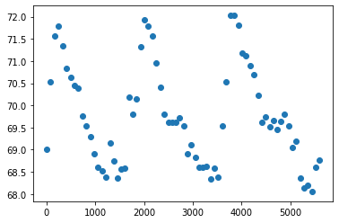

```python
import matplotlib.pyplot as plt

""" Create empty lists for xs and ys to be populated later """
xs = []
ys = []

""" Prepare to read in the data """
f = open('xys.txt','r')

""" Read in the data """
for line in f.readlines():
    line = line.strip(). split(",")
    xs.append(float(line[0]))
    ys.append(float(line[1]))
    #print(line)

f.close()

print(xs)
print(ys)

""" Plot the data """
plt.scatter(xs,ys)
plt.show()
```

# Inputting and Handling Data with the pandas package

We'll use pandas to input the data and manage it so we'll need to import that package.

```python
import pandas as pd
```

These are the data we will be working with using the pandas DataFrame data type

df is often used as a variable name to denote a entity of the pandas DataFrame type

The pandas .read_csv() method is very useful. Note that the data files must have column headings in the first row. You'll, possibly, need to adjust the path to the location of your data file if it is not in the same folder as your default Jupyter folder.

The first data set below (stored in the df_oz DataFrame) is from William S. Cleveland and it is included in a typical R installation, whcih is my sources. These data describe temperature, wind speed, ozone, and radiation levels over time. The second data set, which is from the US Census web site, gives time series data for public (governmental) construction spending and private construction spending. The last data set, which is stored in the df_test DataFrame, gives high school standard of learning (SOL) scores for six course sections of a social studies course.

The double backslash, \\\, is used in the file paths below to avoid issues with escape characters. Alternately, a forward slash could have been used, /.

```python
#df_oz = pd.read_csv('D:\\TeachingMaterials\\BusinessAnalytics\\Visualization\\VizData\\ozone.csv')
df_oz = pd.read_csv('ozone.csv')
```

```python
df_oz
```

|  | ozone | radiation | temperature | wind |
| --- | --- | --- | --- | --- |
| 0 | 41 | 190 | 67 | 7.4 |
| 1 | 36 | 118 | 72 | 8.0 |
| 2 | 12 | 149 | 74 | 12.6 |
| 3 | 18 | 313 | 62 | 11.5 |
| 4 | 23 | 299 | 65 | 8.6 |
| 5 | 19 | 99 | 59 | 13.8 |
| 6 | 8 | 19 | 61 | 20.1 |
| 7 | 16 | 256 | 69 | 9.7 |
| 8 | 11 | 290 | 66 | 9.2 |
| 9 | 14 | 274 | 68 | 10.9 |
| 10 | 18 | 65 | 58 | 13.2 |
| 11 | 14 | 334 | 64 | 11.5 |
| 12 | 34 | 307 | 66 | 12.0 |
| 13 | 6 | 78 | 57 | 18.4 |
| 14 | 30 | 322 | 68 | 11.5 |
| 15 | 11 | 44 | 62 | 9.7 |
| 16 | 1 | 8 | 59 | 9.7 |
| 17 | 11 | 320 | 73 | 16.6 |
| 18 | 4 | 25 | 61 | 9.7 |
| 19 | 32 | 92 | 61 | 12.0 |
| 20 | 23 | 13 | 67 | 12.0 |
| 21 | 45 | 252 | 81 | 14.9 |
| 22 | 115 | 223 | 79 | 5.7 |
| 23 | 37 | 279 | 76 | 7.4 |
| 24 | 29 | 127 | 82 | 9.7 |
| 25 | 71 | 291 | 90 | 13.8 |
| 26 | 39 | 323 | 87 | 11.5 |
| 27 | 23 | 148 | 82 | 8.0 |
| 28 | 21 | 191 | 77 | 14.9 |
| 29 | 37 | 284 | 72 | 20.7 |
| ... | ... | ... | ... | ... |
| 81 | 85 | 188 | 94 | 6.3 |
| 82 | 96 | 167 | 91 | 6.9 |
| 83 | 78 | 197 | 92 | 5.1 |
| 84 | 73 | 183 | 93 | 2.8 |
| 85 | 91 | 189 | 93 | 4.6 |
| 86 | 47 | 95 | 87 | 7.4 |
| 87 | 32 | 92 | 84 | 15.5 |
| 88 | 20 | 252 | 80 | 10.9 |
| 89 | 23 | 220 | 78 | 10.3 |
| 90 | 21 | 230 | 75 | 10.9 |
| 91 | 24 | 259 | 73 | 9.7 |
| 92 | 44 | 236 | 81 | 14.9 |
| 93 | 21 | 259 | 76 | 15.5 |
| 94 | 28 | 238 | 77 | 6.3 |
| 95 | 9 | 24 | 71 | 10.9 |
| 96 | 13 | 112 | 71 | 11.5 |
| 97 | 46 | 237 | 78 | 6.9 |
| 98 | 18 | 224 | 67 | 13.8 |
| 99 | 13 | 27 | 76 | 10.3 |
| 100 | 24 | 238 | 68 | 10.3 |
| 101 | 16 | 201 | 82 | 8.0 |
| 102 | 13 | 238 | 64 | 12.6 |
| 103 | 23 | 14 | 71 | 9.2 |
| 104 | 36 | 139 | 81 | 10.3 |
| 105 | 7 | 49 | 69 | 10.3 |
| 106 | 14 | 20 | 63 | 16.6 |
| 107 | 30 | 193 | 70 | 6.9 |
| 108 | 14 | 191 | 75 | 14.3 |
| 109 | 18 | 131 | 76 | 8.0 |
| 110 | 20 | 223 | 68 | 11.5 |

111 rows × 4 columns

```python
df_oz.head()
```

|  | ozone | radiation | temperature | wind |
| --- | --- | --- | --- | --- |
| 0 | 41 | 190 | 67 | 7.4 |
| 1 | 36 | 118 | 72 | 8.0 |
| 2 | 12 | 149 | 74 | 12.6 |
| 3 | 18 | 313 | 62 | 11.5 |
| 4 | 23 | 299 | 65 | 8.6 |

Before we start plotting, let's look at how you would find out about some of the properties of a DataFrame, atarting with descriptive statistics.

```python
df_oz.describe()
```

|  | ozone | radiation | temperature | wind |
| --- | --- | --- | --- | --- |
| count | 111.000000 | 111.000000 | 111.000000 | 111.000000 |
| mean | 42.099099 | 184.801802 | 77.792793 | 9.938739 |
| std | 33.275969 | 91.152302 | 9.529969 | 3.559218 |
| min | 1.000000 | 7.000000 | 57.000000 | 2.300000 |
| 25% | 18.000000 | 113.500000 | 71.000000 | 7.400000 |
| 50% | 31.000000 | 207.000000 | 79.000000 | 9.700000 |
| 75% | 62.000000 | 255.500000 | 84.500000 | 11.500000 |
| max | 168.000000 | 334.000000 | 97.000000 | 20.700000 |

The .shape command gives a tuple where the element in the 0th position is the number of rows in the DataFrame and the element in the 1st position indicates the number of columns.

```python
df_oz.shape
```

```
(111, 4)
```

```python
df_oz.dtypes
```

```
ozone            int64
radiation        int64
temperature      int64
wind           float64
dtype: object
```

The df_oz DataFrame contains four climatic data series for New York City. Retrieve the column heading to see what they are.

```python
df_oz.columns
```

```
Index(['ozone', 'radiation', 'temperature', 'wind'], dtype='object')
```

```python
df_oz.columns.values
```

```
array(['ozone', 'radiation', 'temperature', 'wind'], dtype=object)
```

Extract a column of data from a DataFrame (a pandas Series data type)

```python
df_oz['temperature']
```

```
0      67
1      72
2      74
3      62
4      65
5      59
6      61
7      69
8      66
9      68
10     58
11     64
12     66
13     57
14     68
```

[output cut: 47 more lines]

```python
type(df_oz['temperature'])
```

```
pandas.core.series.Series
```

Extract a row from a DataFrame by index label.

```python
df_oz.loc[50]
```

```
ozone          16.0
radiation       7.0
temperature    74.0
wind            6.9
Name: 50, dtype: float64
```

Extract a particular row element form a particular column.

```python
df_oz['temperature'].loc[50]
```

```
74
```

```python
df_oz.loc[50]['temperature']
```

```
74.0
```

Select a slice of the temperature series.

```python
df_oz['temperature'].loc[50:100]
```

```
50     74
51     86
52     85
53     82
54     86
55     88
56     86
57     83
58     81
59     81
60     81
61     82
62     89
63     90
64     90
```

[output cut: 37 more lines]

Select a slice of multiple series.

```python
df_oz[['ozone','temperature']].loc[50:100]
```

|  | ozone | temperature |
| --- | --- | --- |
| 50 | 16 | 74 |
| 51 | 80 | 86 |
| 52 | 108 | 85 |
| 53 | 20 | 82 |
| 54 | 52 | 86 |
| 55 | 82 | 88 |
| 56 | 50 | 86 |
| 57 | 64 | 83 |
| 58 | 59 | 81 |
| 59 | 39 | 81 |
| 60 | 9 | 81 |
| 61 | 16 | 82 |
| 62 | 122 | 89 |
| 63 | 89 | 90 |
| 64 | 110 | 90 |
| 65 | 44 | 86 |
| 66 | 28 | 82 |
| 67 | 65 | 80 |
| 68 | 22 | 77 |
| 69 | 59 | 79 |
| 70 | 23 | 76 |
| 71 | 31 | 78 |
| 72 | 44 | 78 |
| 73 | 21 | 77 |
| 74 | 9 | 72 |
| 75 | 45 | 79 |
| 76 | 168 | 81 |
| 77 | 73 | 86 |
| 78 | 76 | 97 |
| 79 | 118 | 94 |
| 80 | 84 | 96 |
| 81 | 85 | 94 |
| 82 | 96 | 91 |
| 83 | 78 | 92 |
| 84 | 73 | 93 |
| 85 | 91 | 93 |
| 86 | 47 | 87 |
| 87 | 32 | 84 |
| 88 | 20 | 80 |
| 89 | 23 | 78 |
| 90 | 21 | 75 |
| 91 | 24 | 73 |
| 92 | 44 | 81 |
| 93 | 21 | 76 |
| 94 | 28 | 77 |
| 95 | 9 | 71 |
| 96 | 13 | 71 |
| 97 | 46 | 78 |
| 98 | 18 | 67 |
| 99 | 13 | 76 |
| 100 | 24 | 68 |

```python
df_oz.index
```

```
RangeIndex(start=0, stop=111, step=1)
```

# matplotlib and Object Orientation

The top-level object is the figure, which contains many sub-copmponents, including a figure title, which is formally called the suptitle, and the axes, which contain the visual graph elements. You can say the the suptitle and axes objects are child objects of the figure object.

[figure not shown]

Next we can drill down into the axes object and observe its child objects, which include the legend, the y-axis, the x-axis, vertical and horizontal lines, and grid lines.

[figure not shown]

Although we have looked at only a small fraction of the objects within a matplotlib figure, we can view the hierarchical structure of the objects we have observed in the succession above.

[figure not shown]

# Using pandas and the matplotlib Object Model

Let's investigate the relationship of ozone level to wind speed with a scatter plot.

```python
def simple():
    a_list =[0, 1, 2]
    a_num=98
    return a_list, a_num
simple()
```

```
([0, 1, 2], 98)
```

```python
mylist, mynum=simple() #to create two variables that catch what the function returns.
print(mylist)
print(mynum)
```

```
[0, 1, 2]
98
```

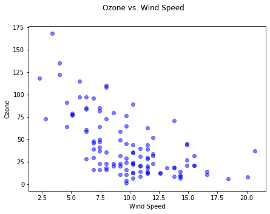

```python
""" Format of the scatterplot method is as follows: ax.scatter(x-series, y-series) """
fig, ax = plt.subplots()  #fig and ax are two variables;
"""
ax.scatter() statement creates scatterplot
The 'alpha' parameter controls dot transparency: 1 = solid, <1 = various transparency levels, 0 = no mark
The c parameter designates color of the dots: 'b' stands for blue
"""
ax.scatter(df_oz['wind'], df_oz['ozone'], alpha=0.5, c = 'b')
fig.suptitle('Ozone vs. Wind Speed')   # Graph title
ax.xaxis.set_label_text('Wind Speed')  # x-axis caption
ax.yaxis.set_label_text('Ozone')       # y-axis caption
fig.set_size_inches(7,5)
plt.show()
```

Here's ozone level versus solar radiation. What relationship do you see?

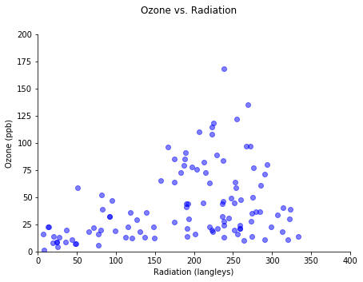

```python
""" Format of the scatterplot method is as follows: ax.scatter(x-series, y-series) """
fig, ax = plt.subplots()
"""
ax.scatter() statement creates scatterplot
The 'alpha' parameter controls dot transparency: 1 = solid, <1 = various transparency levels, 0 = no mark
The c parameter designates color of the dots: 'b' stands for blue
"""
ax.scatter(df_oz['radiation'], df_oz['ozone'], alpha=0.5, c = 'b')    # the 'alpha' parameter controls dot opacity from 0 to 1. 0 is transparent and1 is solid.
fig.suptitle('Ozone vs. Radiation')
ax.xaxis.set_label_text('Radiation (langleys)')
ax.yaxis.set_label_text('Ozone (ppb)')
ax.set_xlim(0,400)                                                    # Set min and max for y axis
ax.set_ylim(0,200)
ax.spines['right'].set_visible(False)  #removes the borders. spines=boarder
ax.spines['top'].set_visible(False)
fig.set_size_inches(7,5)   # set the size of the graph, the larger the number you put in, the larger the picture is.
plt.show()
```

# Distributional Data: Histograms and Bar Charts

Let's look at some distributional data from a database that contains student scores for two tests, one taken at the beginning of the year and one at the end of the year. Each student's scores are recorded along with their isntructor, school number, and course section number. Here are the column names:

```python
#df_test = pd.read_csv('D:/TeachingMaterials/BusinessAnalytics/Visualization/MSBAST1DataPrograms\\test.csv')
df_test = pd.read_csv('test.csv')
```

```python
df_test
```

|  | StudentIdentifier | BegYearTestScore | EndYearTestScore | InstructorName | SchoolNumber | CourseSectionNumber |
| --- | --- | --- | --- | --- | --- | --- |
| 0 | 1 | 56 | 75 | Smith | 1 | 1 |
| 1 | 2 | 42 | 72 | Smith | 1 | 1 |
| 2 | 3 | 35 | 83 | Smith | 1 | 1 |
| 3 | 4 | 50 | 69 | Smith | 1 | 1 |
| 4 | 5 | 51 | 76 | Smith | 1 | 1 |
| 5 | 6 | 35 | 67 | Smith | 1 | 1 |
| 6 | 7 | 37 | 73 | Smith | 1 | 1 |
| 7 | 8 | 57 | 76 | Smith | 1 | 1 |
| 8 | 9 | 40 | 70 | Smith | 1 | 1 |
| 9 | 10 | 64 | 80 | Smith | 1 | 1 |
| 10 | 11 | 52 | 79 | Smith | 1 | 1 |
| 11 | 12 | 43 | 83 | Smith | 1 | 1 |
| 12 | 13 | 46 | 72 | Smith | 1 | 1 |
| 13 | 14 | 40 | 84 | Smith | 1 | 1 |
| 14 | 15 | 45 | 76 | Smith | 1 | 1 |
| 15 | 16 | 57 | 69 | Smith | 1 | 1 |
| 16 | 17 | 61 | 65 | Smith | 1 | 1 |
| 17 | 18 | 40 | 72 | Smith | 1 | 1 |
| 18 | 19 | 39 | 77 | Smith | 1 | 1 |
| 19 | 20 | 61 | 82 | Smith | 1 | 1 |
| 20 | 21 | 59 | 70 | Smith | 1 | 1 |
| 21 | 22 | 59 | 82 | Smith | 1 | 1 |
| 22 | 23 | 62 | 67 | Smith | 1 | 1 |
| 23 | 24 | 63 | 84 | Smith | 1 | 1 |
| 24 | 25 | 37 | 65 | Smith | 1 | 1 |
| 25 | 26 | 37 | 68 | Smith | 1 | 1 |
| 26 | 27 | 40 | 66 | Smith | 1 | 1 |
| 27 | 28 | 60 | 82 | Smith | 1 | 1 |
| 28 | 29 | 60 | 80 | Smith | 1 | 1 |
| 29 | 30 | 44 | 76 | Smith | 1 | 1 |
| ... | ... | ... | ... | ... | ... | ... |
| 180 | 6 | 56 | 83 | Green | 1 | 5 |
| 181 | 7 | 59 | 73 | Green | 1 | 5 |
| 182 | 8 | 47 | 69 | Green | 1 | 5 |
| 183 | 9 | 49 | 70 | Green | 1 | 5 |
| 184 | 10 | 49 | 78 | Green | 1 | 5 |
| 185 | 11 | 42 | 66 | Green | 1 | 5 |
| 186 | 12 | 64 | 83 | Green | 1 | 5 |
| 187 | 13 | 63 | 69 | Green | 1 | 5 |
| 188 | 14 | 57 | 80 | Green | 1 | 5 |
| 189 | 15 | 63 | 84 | Green | 1 | 5 |
| 190 | 16 | 56 | 84 | Green | 1 | 5 |
| 191 | 17 | 57 | 71 | Green | 1 | 5 |
| 192 | 18 | 49 | 74 | Green | 1 | 5 |
| 193 | 19 | 62 | 73 | Green | 1 | 5 |
| 194 | 20 | 45 | 70 | Green | 1 | 5 |
| 195 | 21 | 46 | 69 | Green | 1 | 5 |
| 196 | 22 | 57 | 70 | Green | 1 | 5 |
| 197 | 23 | 64 | 84 | Green | 1 | 5 |
| 198 | 24 | 51 | 74 | Green | 1 | 5 |
| 199 | 25 | 62 | 84 | Green | 1 | 5 |
| 200 | 26 | 43 | 81 | Green | 1 | 5 |
| 201 | 27 | 50 | 80 | Green | 1 | 5 |
| 202 | 28 | 52 | 83 | Green | 1 | 5 |
| 203 | 29 | 60 | 70 | Green | 1 | 5 |
| 204 | 30 | 48 | 84 | Green | 1 | 5 |
| 205 | 31 | 48 | 76 | Green | 1 | 5 |
| 206 | 32 | 62 | 84 | Green | 1 | 5 |
| 207 | 33 | 44 | 84 | Green | 1 | 5 |
| 208 | 34 | 62 | 69 | Green | 1 | 5 |
| 209 | 35 | 57 | 76 | Green | 1 | 5 |

210 rows × 6 columns

```python
df_test.columns.values
```

```
array(['StudentIdentifier', 'BegYearTestScore', 'EndYearTestScore',
       'InstructorName', 'SchoolNumber', 'CourseSectionNumber'],
      dtype=object)
```

Here's what the data look like:

```python
df_test.head()  # by default, gives you the first 5 rows. df_test.head(n=3)
```

|  | StudentIdentifier | BegYearTestScore | EndYearTestScore | InstructorName | SchoolNumber | CourseSectionNumber |
| --- | --- | --- | --- | --- | --- | --- |
| 0 | 1 | 56 | 75 | Smith | 1 | 1 |
| 1 | 2 | 42 | 72 | Smith | 1 | 1 |
| 2 | 3 | 35 | 83 | Smith | 1 | 1 |
| 3 | 4 | 50 | 69 | Smith | 1 | 1 |
| 4 | 5 | 51 | 76 | Smith | 1 | 1 |

```python
#automately generate a comlume of index
```

Before we proceed, let's clean things up a bit by using the StudentIdentifier data as the index. It is unnecessary to have both the (automatic) integer index and the StudentIdentifier.

```python
df_test1 = df_test.set_index('StudentIdentifier') # change the index cloumn to what we want.
# if we don't assign it to a variable, it seems like the data frame has been changed, but no.
```

```python
df_test1.head()
```

| StudentIdentifier | BegYearTestScore | EndYearTestScore | InstructorName | SchoolNumber | CourseSectionNumber |
| --- | --- | --- | --- | --- | --- |
| 1 | 56 | 75 | Smith | 1 | 1 |
| 2 | 42 | 72 | Smith | 1 | 1 |
| 3 | 35 | 83 | Smith | 1 | 1 |
| 4 | 50 | 69 | Smith | 1 | 1 |
| 5 | 51 | 76 | Smith | 1 | 1 |

The pandas.unique() method provides easy access to a list of the distinct entries in each column, for example to find what instructors are represented in the database.

```python
df_test1['InstructorName'].unique()
```

```
array(['Smith', 'Jones', 'Green'], dtype=object)
```

Let's filter the rows, choosing only those rows where Smith is the instructor

```python
df_test1.loc[df_test1['InstructorName'] == 'Smith']
```

| StudentIdentifier | BegYearTestScore | EndYearTestScore | InstructorName | SchoolNumber | CourseSectionNumber |
| --- | --- | --- | --- | --- | --- |
| 1 | 56 | 75 | Smith | 1 | 1 |
| 2 | 42 | 72 | Smith | 1 | 1 |
| 3 | 35 | 83 | Smith | 1 | 1 |
| 4 | 50 | 69 | Smith | 1 | 1 |
| 5 | 51 | 76 | Smith | 1 | 1 |
| 6 | 35 | 67 | Smith | 1 | 1 |
| 7 | 37 | 73 | Smith | 1 | 1 |
| 8 | 57 | 76 | Smith | 1 | 1 |
| 9 | 40 | 70 | Smith | 1 | 1 |
| 10 | 64 | 80 | Smith | 1 | 1 |
| 11 | 52 | 79 | Smith | 1 | 1 |
| 12 | 43 | 83 | Smith | 1 | 1 |
| 13 | 46 | 72 | Smith | 1 | 1 |
| 14 | 40 | 84 | Smith | 1 | 1 |
| 15 | 45 | 76 | Smith | 1 | 1 |
| 16 | 57 | 69 | Smith | 1 | 1 |
| 17 | 61 | 65 | Smith | 1 | 1 |
| 18 | 40 | 72 | Smith | 1 | 1 |
| 19 | 39 | 77 | Smith | 1 | 1 |
| 20 | 61 | 82 | Smith | 1 | 1 |
| 21 | 59 | 70 | Smith | 1 | 1 |
| 22 | 59 | 82 | Smith | 1 | 1 |
| 23 | 62 | 67 | Smith | 1 | 1 |
| 24 | 63 | 84 | Smith | 1 | 1 |
| 25 | 37 | 65 | Smith | 1 | 1 |
| 26 | 37 | 68 | Smith | 1 | 1 |
| 27 | 40 | 66 | Smith | 1 | 1 |
| 28 | 60 | 82 | Smith | 1 | 1 |
| 29 | 60 | 80 | Smith | 1 | 1 |
| 30 | 44 | 76 | Smith | 1 | 1 |
| ... | ... | ... | ... | ... | ... |
| 6 | 46 | 68 | Smith | 1 | 4 |
| 7 | 61 | 71 | Smith | 1 | 4 |
| 8 | 52 | 78 | Smith | 1 | 4 |
| 9 | 56 | 82 | Smith | 1 | 4 |
| 10 | 63 | 84 | Smith | 1 | 4 |
| 11 | 60 | 65 | Smith | 1 | 4 |
| 12 | 39 | 66 | Smith | 1 | 4 |
| 13 | 40 | 79 | Smith | 1 | 4 |
| 14 | 48 | 77 | Smith | 1 | 4 |
| 15 | 42 | 79 | Smith | 1 | 4 |
| 16 | 48 | 79 | Smith | 1 | 4 |
| 17 | 40 | 83 | Smith | 1 | 4 |
| 18 | 61 | 66 | Smith | 1 | 4 |
| 19 | 60 | 81 | Smith | 1 | 4 |
| 20 | 51 | 78 | Smith | 1 | 4 |
| 21 | 59 | 74 | Smith | 1 | 4 |
| 22 | 40 | 71 | Smith | 1 | 4 |
| 23 | 54 | 76 | Smith | 1 | 4 |
| 24 | 61 | 68 | Smith | 1 | 4 |
| 25 | 47 | 71 | Smith | 1 | 4 |
| 26 | 56 | 80 | Smith | 1 | 4 |
| 27 | 64 | 83 | Smith | 1 | 4 |
| 28 | 38 | 81 | Smith | 1 | 4 |
| 29 | 60 | 73 | Smith | 1 | 4 |
| 30 | 58 | 75 | Smith | 1 | 4 |
| 31 | 59 | 76 | Smith | 1 | 4 |
| 32 | 53 | 75 | Smith | 1 | 4 |
| 33 | 57 | 80 | Smith | 1 | 4 |
| 34 | 63 | 84 | Smith | 1 | 4 |
| 35 | 51 | 68 | Smith | 1 | 4 |

70 rows × 5 columns

Let's plot a frequency histogram of this data for the year end test scores.

```python
df_test1.loc[df_test1['InstructorName'] == 'Smith']['EndYearTestScore']
```

```
StudentIdentifier
1     75
2     72
3     83
4     69
5     76
6     67
7     73
8     76
9     70
10    80
11    79
12    83
13    72
14    84
```

[output cut: 48 more lines]

```python
df_test1["EndYearTestScore"].loc[df_test1['InstructorName'] == 'Smith']
```

```
StudentIdentifier
1     75
2     72
3     83
4     69
5     76
6     67
7     73
8     76
9     70
10    80
11    79
12    83
13    72
14    84
```

[output cut: 48 more lines]

Here's a frequency histogram for Instructor Smith's students at the end of the school year using the ax.hist() method, which converts the data into a frequency histogram.

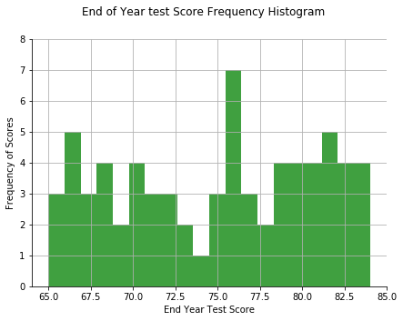

```python
fig, ax = plt.subplots()
ax.hist(x = df_test1.loc[df_test1['InstructorName'] == 'Smith']['EndYearTestScore'], bins = 20, facecolor='g', alpha=0.75)

fig.suptitle('End of Year test Score Frequency Histogram')
fig.set_size_inches(7,5)

ax.xaxis.set_label_text('End Year Test Score')
ax.xaxis.set_tick_params(which = 'both', top = False, bottom = True, labelbottom = True)  # Turn top x axis tick marks off
# which="both": there is ai x-axis on the top too
ax.yaxis.set_label_text('Frequency of Scores')
ax.yaxis.set_tick_params(which = 'both', right = False, left = True, labelleft = True)   # Turn right y axis tick marks off

ax.set_xlim(64, 85)
ax.set_ylim(0, 8)
ax.spines['right'].set_visible(False)
ax.spines['top'].set_visible(False)
ax.grid(True)  # turn on the grid on the background, not neccessarily need it.
```

A bar chart can be used to create a histogram also, but using this chart type requires that the data be processed into frequency histogram format before plotting.

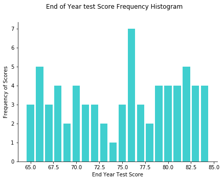

```python
""" Create frequency histogram data from DataFrame """
scores = df_test1.loc[df_test1['InstructorName'] == 'Smith']['EndYearTestScore']
scores = dict(scores.value_counts())  # creats a dic
maxx = max(scores)    # gives the highest value, not the key.
minx = min(scores)
x = [i for i in range(minx,maxx+1)]   # creates a list of x that starts the lowest score to the highest
freq = [scores[i] for i in range(minx,maxx+1)]  # +1 to include the whole number

""" Plot frequency histogram data """
fig, ax = plt.subplots()
ax.bar(x=x,height=freq, color='c', alpha=0.75)  # bar grapg commend: x is the list of x, give height parameter to freq list.

fig.suptitle('End of Year test Score Frequency Histogram')
fig.set_size_inches(7,5)

ax.xaxis.set_label_text('End Year Test Score')
ax.xaxis.set_tick_params(which = 'both', top = False, bottom = True, labelbottom = True)  # Turn top x axis tick marks off

ax.yaxis.set_label_text('Frequency of Scores')
ax.yaxis.set_tick_params(which = 'both', right = False, left = True, labelleft = True)   # Turn right y axis tick marks off

#ax.set_xticks(range(minx,maxx+1))
#ax.set_xticklabels(range(minx,maxx+1))

#ax.set_xlim(64, 85)
#ax.set_ylim(0, 8)
ax.spines['right'].set_visible(False)
ax.spines['top'].set_visible(False)
ax.grid(False)

# this graph is not good since the tick marks are off
```

Block of code from the cell above that creates a dictionary with the frequency histogram data.

# Excercise: first appraoch

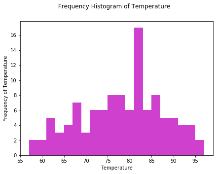

```python
fig, ax = plt.subplots()
ax.hist(x = df_oz['temperature'], bins = 20, facecolor='m', alpha=0.75)
fig.suptitle(" Frequency Histogram of Temperature")
fig.set_size_inches(7,5)

ax.xaxis.set_label_text('Temperature')
ax.xaxis.set_tick_params(which = 'both', top = False, bottom = True, labelbottom = True)
ax.yaxis.set_label_text('Frequency of Temperature')
ax.yaxis.set_tick_params(which = 'both', right = False, left = True, labelleft = True)
```

# second approach

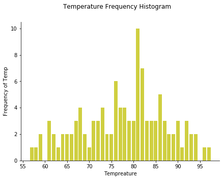

```python
score=df_oz["temperature"]
score = dict(score.value_counts())
temp = list(score.keys())
#temp.sort()
max1 = max(temp)
min1 = min(temp)
x =[ i for i in range(min1, max1+1)]
freq = [score[i] if i in temp else 0 for i in range(min1, max1+1)]
fig, ax = plt.subplots()
ax.bar(x=x,height=freq, color='y', alpha=0.75)  # bar grapg commend: x is the list of x, give height parameter to freq list.

fig.suptitle('Temperature Frequency Histogram')
fig.set_size_inches(7,5)

ax.xaxis.set_label_text('Tempreature')
ax.xaxis.set_tick_params(which = 'both', top = False, bottom = True, labelbottom = True)  # Turn top x axis tick marks off

ax.yaxis.set_label_text('Frequency of Temp')
ax.yaxis.set_tick_params(which = 'both', right = False, left = True, labelleft = True)   # Turn right y axis tick marks off

#ax.set_xticks(range(minx,maxx+1))
#ax.set_xticklabels(range(minx,maxx+1))

#ax.set_xlim(64, 85)
#ax.set_ylim(0, 8)
ax.spines['right'].set_visible(False)
ax.spines['top'].set_visible(False)
ax.grid(False)
```

```python
scores = df_test1.loc[df_test1['InstructorName'] == 'Smith']['EndYearTestScore']
scores = dict(scores.value_counts())
scores
```

```
{76: 7,
 82: 5,
 66: 5,
 84: 4,
 81: 4,
 80: 4,
 79: 4,
 68: 4,
 83: 4,
 70: 4,
 71: 3,
 67: 3,
 65: 3,
 72: 3,
 75: 3,
 77: 3,
 73: 2,
 69: 2,
 78: 2,
 74: 1}
```

Here's one way to show a comparison of Smith's and Green's student scores at the end of the year. Do you like the graph? Is it easy to read? Do you have any suggestions for improvement?

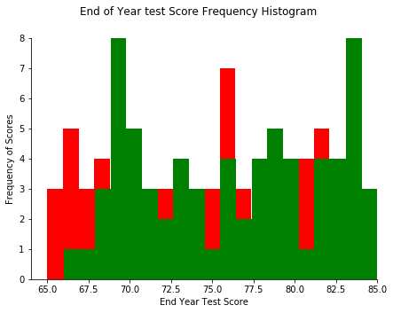

```python
fig, ax = plt.subplots()

ax.hist(x = df_test1.loc[df_test1['InstructorName'] == 'Smith']['EndYearTestScore'], bins = 20, facecolor='r')
ax.hist(x = df_test1.loc[df_test1['InstructorName'] == 'Green']['EndYearTestScore'], bins = 20, facecolor='g')

fig.suptitle('End of Year test Score Frequency Histogram')
fig.set_size_inches(7,5)

ax.xaxis.set_label_text('End Year Test Score')
ax.xaxis.set_tick_params(which = 'both', top = False, bottom = True, labelbottom = True)  # Turn top x axis tick marks off

ax.yaxis.set_label_text('Frequency of Scores')
ax.yaxis.set_tick_params(which = 'both', right = False, left = True, labelleft = True)   # Turn right y axis tick marks off

ax.set_xlim(64, 85)
ax.set_ylim(0, 8)
ax.spines['right'].set_visible(False)
ax.spines['top'].set_visible(False)
```

Well, that graph is poor and, actually, unacceptable. You cannot see how high the bars/columns are for one of the series at many points on the x-axis. Possibly, this graph might be improved if we made the columns partially opaque.

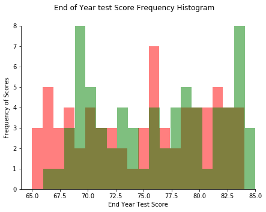

```python
fig, ax = plt.subplots()

ax.hist(x = df_test1.loc[df_test1['InstructorName'] == 'Smith']['EndYearTestScore'], bins = 20, facecolor='r', alpha=0.5)
ax.hist(x = df_test1.loc[df_test1['InstructorName'] == 'Green']['EndYearTestScore'], bins = 20, facecolor='g', alpha=0.5)

fig.suptitle('End of Year test Score Frequency Histogram')
fig.set_size_inches(7,5)

ax.xaxis.set_label_text('End Year Test Score')
ax.xaxis.set_tick_params(which = 'both', top = False, bottom = True, labelbottom = True)  # Turn top x axis tick marks off

ax.yaxis.set_label_text('Frequency of Scores')
ax.yaxis.set_tick_params(which = 'both', right = False, left = True, labelleft = True)   # Turn right y axis tick marks off

ax.set_xlim(64, 85)
ax.set_ylim(0, 8)
ax.spines['right'].set_visible(False)
ax.spines['top'].set_visible(False)
```

That approach was unsatisfactory also. Perhaps it would help to plot the bars/columns side by side?

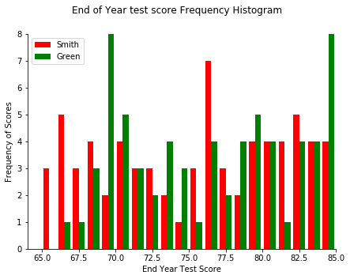

```python
fig, ax = plt.subplots()

n, bins, patches = ax.hist((df_test1.loc[df_test1['InstructorName'] == 'Smith']['EndYearTestScore'], \
         df_test1.loc[df_test1['InstructorName'] == 'Green']['EndYearTestScore']), bins = 20, stacked = False)
for i in range(len(patches)):
    if i%2 == 0:
        plt.setp(patches[i],'facecolor','r')
    else:
        plt.setp(patches[i],'facecolor','g')

fig.suptitle('End of Year test score Frequency Histogram')
fig.set_size_inches(7,5)

ax.xaxis.set_label_text('End Year Test Score')
ax.xaxis.set_tick_params(which = 'both', top = False, bottom = True, labelbottom = True)  # Turn top x axis tick marks off

ax.yaxis.set_label_text('Frequency of Scores')
ax.yaxis.set_tick_params(which = 'both', right = False, left = True, labelleft = True)   # Turn right y axis tick marks off

ax.set_xlim(64, 85)
ax.set_ylim(0, 8)
ax.spines['right'].set_visible(False)
ax.spines['top'].set_visible(False)
ax.legend(['Smith','Green'], loc=2)
```

That approach was unsatisfactory as well. At least we demonstrated some of the techniques available with matplotlib. We will show a much superior method later on.

```python
df_test2 = pd.concat([df_test1.loc[df_test1['InstructorName'] == 'Smith']['EndYearTestScore'],df_test1.loc[df_test1['InstructorName'] == 'Green']['EndYearTestScore']], axis = 1)
df_test2.columns = ['Smith','Green']
```

```python
df_test1.loc[df_test1['InstructorName'] == 'Green']['EndYearTestScore']
```

```
StudentIdentifier
1     83
2     69
3     78
4     82
5     82
6     69
7     67
8     76
9     71
10    82
11    73
12    82
13    68
14    69
```

[output cut: 48 more lines]

```python
df_test2
```

| StudentIdentifier | Smith | Green |
| --- | --- | --- |
| 1 | 75 | 83 |
| 2 | 72 | 69 |
| 3 | 83 | 78 |
| 4 | 69 | 82 |
| 5 | 76 | 82 |
| 6 | 67 | 69 |
| 7 | 73 | 67 |
| 8 | 76 | 76 |
| 9 | 70 | 71 |
| 10 | 80 | 82 |
| 11 | 79 | 73 |
| 12 | 83 | 82 |
| 13 | 72 | 68 |
| 14 | 84 | 69 |
| 15 | 76 | 77 |
| 16 | 69 | 85 |
| 17 | 65 | 80 |
| 18 | 72 | 78 |
| 19 | 77 | 77 |
| 20 | 82 | 76 |
| 21 | 70 | 85 |
| 22 | 82 | 79 |
| 23 | 67 | 70 |
| 24 | 84 | 68 |
| 25 | 65 | 73 |
| 26 | 68 | 78 |
| 27 | 66 | 79 |
| 28 | 82 | 85 |
| 29 | 80 | 72 |
| 30 | 76 | 74 |
| ... | ... | ... |
| 6 | 68 | 83 |
| 7 | 71 | 73 |
| 8 | 78 | 69 |
| 9 | 82 | 70 |
| 10 | 84 | 78 |
| 11 | 65 | 66 |
| 12 | 66 | 83 |
| 13 | 79 | 69 |
| 14 | 77 | 80 |
| 15 | 79 | 84 |
| 16 | 79 | 84 |
| 17 | 83 | 71 |
| 18 | 66 | 74 |
| 19 | 81 | 73 |
| 20 | 78 | 70 |
| 21 | 74 | 69 |
| 22 | 71 | 70 |
| 23 | 76 | 84 |
| 24 | 68 | 74 |
| 25 | 71 | 84 |
| 26 | 80 | 81 |
| 27 | 83 | 80 |
| 28 | 81 | 83 |
| 29 | 73 | 70 |
| 30 | 75 | 84 |
| 31 | 76 | 76 |
| 32 | 75 | 84 |
| 33 | 80 | 84 |
| 34 | 84 | 69 |
| 35 | 68 | 76 |

70 rows × 2 columns

Here's a boxplot of Smith's end of year student test scores.

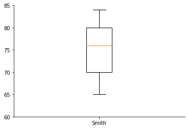

```python
fig, ax = plt.subplots()

ax.boxplot(df_test1.loc[df_test1['InstructorName'] == 'Smith']['EndYearTestScore'])

ax.yaxis.axes.set_ylim(60,85)
ax.set_xticklabels(['Smith'])

# Reducing clutter
ax.xaxis.set_tick_params(which = 'both', top = False, bottom = True, labelbottom = True)  # Turn top x axis tick marks off
ax.yaxis.set_tick_params(which = 'both', right = False, left = True, labelleft = True)   # Turn right y axis tick marks off
ax.spines['right'].set_visible(False)
ax.spines['top'].set_visible(False)
```

Code for comparing Smith and Green

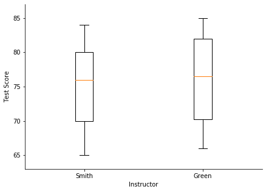

```python
# Get data
data = []       # create an empty Python list; sublists will be appended for each boxplot
data.append(df_test1.loc[df_test1['InstructorName'] == 'Smith']['EndYearTestScore'])
data.append(df_test1.loc[df_test1['InstructorName'] == 'Green']['EndYearTestScore'])
data_min = min([min(sublist) for sublist in data])  # this and the following 3 lines automatically size the graph to the data
data_max = max([max(sublist) for sublist in data])  # while providing buffer space

fig, ax = plt.subplots()

fig.set_figheight(5)
fig.set_figwidth(7)
ax.boxplot(data)

ax.yaxis.axes.set_ylim(data_min - 2, data_max + 2)  # ylimits. hardcoding is not good. -2, +2 gives some space above and below
ax.set_xticklabels(['Smith','Green'])
ax.set_ylabel('Test Score')
ax.set_xlabel('Instructor')

# Reducing clutter
ax.xaxis.set_tick_params(which = 'both', top = False, bottom = True, labelbottom = True)  # Turn top x axis tick marks off
ax.yaxis.set_tick_params(which = 'both', right = False, left = True, labelleft = True)   # Turn right y axis tick marks off
ax.spines['right'].set_visible(False)
ax.spines['top'].set_visible(False)
```

Code for comparing Smith, Jones, and Green with a more flexible approach for selecting instructors to compare.

```python
df_test1["InstructorName"].unique().tolist()
```

[output not shown]

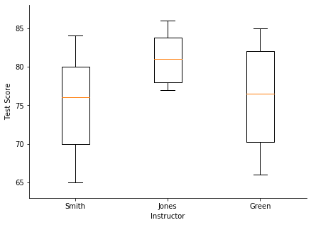

```python
# Get data
instructors = df_test1["InstructorName"].unique().tolist()#['Smith','Green','Jones']
data = []       # create an empty Python list; sublists will be appended for each boxplot
for instructor in instructors:
    data.append(df_test1.loc[df_test1['InstructorName'] == instructor]['EndYearTestScore'])
data_min = min([min(sublist) for sublist in data])  # this and the following 3 lines automatically size the graph to the data
data_max = max([max(sublist) for sublist in data])  # while providing buffer space

fig, ax = plt.subplots()

""" Alternate method for adjusting the figure size """
fig.set_figheight(5)
fig.set_figwidth(7)
#fig.add_axes

ax.boxplot(data)

ax.set_ylim(data_min - 2, data_max + 2)
ax.set_xticklabels(instructors)
ax.set_ylabel('Test Score')
ax.set_xlabel('Instructor')
ax.set_xticks(range(1,len(instructors)+1),instructors)

# Reducing clutter
ax.xaxis.set_tick_params(which = 'both', top = False, bottom = True, labelbottom = True)  # Turn top x axis tick marks off
ax.yaxis.set_tick_params(which = 'both', right = False, left = True, labelleft = True)   # Turn right y axis tick marks off
ax.spines['right'].set_visible(False)
ax.spines['top'].set_visible(False)
```

A box plot can be drawn more simply without using the fig, ax approach, but control over all teh chart elements is more difficult if impossible.

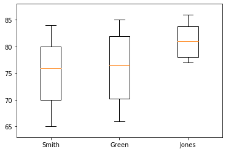

```python
data = []       # create an empty Python list; sublists will be appended for each boxplot
instructors = ['Smith','Green','Jones']
for instructor in instructors:
    data.append(list(df_test1.loc[df_test1['InstructorName'] == instructor]['EndYearTestScore']))
plt.boxplot(data)
plt.xticks(range(1,len(instructors)+1),instructors)
data_min = min([min(sublist) for sublist in data])  # this and the following 3 lines automatically size the graph to the data
data_max = max([max(sublist) for sublist in data])  # while providing buffer space
plt.ylim([data_min - 2, data_max + 2])   # alternate method for setting y-axis limits
plt.show()
```

# Pareto Diagrams

Plotting the components of the U.S. budget.

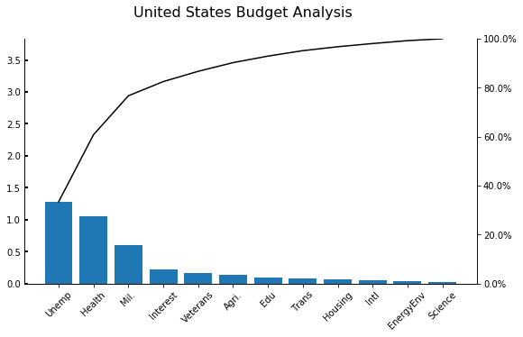

```python
import matplotlib.pyplot as plt

# Data
bdata = [1.28,1.05,0.6093,0.22195,0.16063,0.1357,0.10226,0.08499,0.06148,0.05022,0.04485,0.02981]
blabels = ['Unemp','Health','Mil.','Interest', 'Veterans','Agri.','Edu','Trans','Housing','Intl','EnergyEnv','Science']
xs = range(len(bdata))
bdata_cum = []
for i in range(len(bdata)):
    bdata_cum.append(sum(bdata[0:i+1])/sum(bdata))   # calculating the cummunlative percentage, +1 to include the last element

fig, ax = plt.subplots()
fig.suptitle('United States Budget Analysis', fontsize = 16)

# Set bar chart parameters
ax.bar(xs,bdata, align='center')
ax.set_ylim(0,sum(bdata))
ax.set_xticks(xs)
ax.set_xticklabels(blabels, rotation = 45)
ax.spines['top'].set_visible(False)
ax.grid(False)

ax.tick_params(axis = 'y', which = 'both', direction = 'in', width = 2, color = 'black')

# Set line chart paramters and assign the second y axis
ax1 = ax.twinx()  # use the same x-axis, and creating another y-axis
ax1.plot(xs,bdata_cum,color='k')
ax1.set_ylim(0,1)
ax1.set_yticklabels(['{:1.1f}%'.format(x*100) for x in ax1.get_yticks()]) #formatting. gives me one decimal place. if {:1.0f} then no floating point
ax1.spines['top'].set_visible(False)
ax1.grid(False)

#fig.set_figwidth(9)
#fig.set_figheight(5)
fig.set_size_inches(9,5)
fig.savefig('pareto.jpg', dpi=2000)  # save my image in the same folder
plt.show()
```

```python
x = 1.2345
'{:1.2f}%'. format(x)
```

```
'1.23%'
```

In the following code a typical version of a Pareto chart is shown where bars are shown for only the most frequent items.

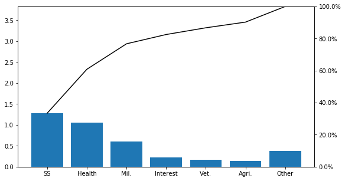

```python
import matplotlib.pyplot as plt

# Data
blabels1 = ['SS','Health','Mil.','Interest', 'Vet.','Agri.','Other']
bindex = 6
bother = sum(bdata[bindex:])
bdata1 = bdata[:bindex] + [bother]
xs = range(len(bdata1))
bdata_cum = []
for i in range(len(bdata1)):
    bdata_cum.append(sum(bdata1[0:i+1])/sum(bdata1))

fig, ax = plt.subplots()
fig.set_figwidth(9)
fig.set_figheight(5)

# Bar chart settings
ax.set_xticks(xs)
ax.set_xticklabels(blabels1)
ax.bar(xs,bdata1, align='center')
ax.set_ylim(0,sum(bdata1))

# Line chart settings
ax1 = ax.twinx()
ax1.plot(xs,bdata_cum,color='k')
ax1.set_ylim(0,1)
ax1.set_yticklabels(['{:1.1f}%'.format(x*100) for x in ax1.get_yticks()])
plt.show()
```

# Construction Data

This is the data that you will use for your Storytelling & Visualization aassignment due at the end of the course.

```python
df_con = pd.read_csv('ConstructionTimeSeriesDataV2.csv')
```

```python
df_con.head()
```

|  | Month | Month-Year | Total Construction | Private Construction | Public Construction |
| --- | --- | --- | --- | --- | --- |
| 0 | 1 | Jan-02 | 59516 | 45273 | 14243 |
| 1 | 2 | Feb-02 | 58588 | 44475 | 14113 |
| 2 | 3 | Mar-02 | 63782 | 49396 | 14386 |
| 3 | 4 | Apr-02 | 69504 | 53283 | 16221 |
| 4 | 5 | May-02 | 73384 | 55009 | 18375 |

```python
df_con.dtypes  # pandas call str a object
```

```
Month                    int64
Month-Year              object
Total Construction       int64
Private Construction     int64
Public Construction      int64
dtype: object
```

```python
df_con['Total Construction']
```

```
0      59516
1      58588
2      63782
3      69504
4      73384
5      77182
6      78863
7      79460
8      76542
9      75710
10     71362
11     63984
12     59877
13     58526
14     64506
```

[output cut: 47 more lines]

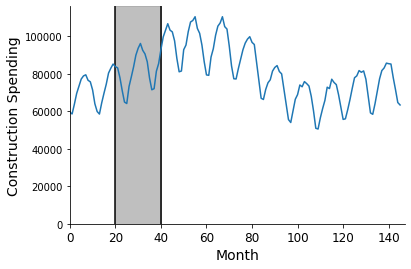

```python
x = df_con.index
y = df_con['Total Construction']
fig, ax = plt.subplots()
fig.set_size_inches(6,4)               # figure must be resized prior to .plot() statement
ax.plot(x,y,label='Total Construction')
ax.set_xlabel('Month',fontsize=14)                      # Title for the horizontal axis
ax.set_ylabel('Construction Spending',fontsize=14)      # Title for the vertical axis
ax.spines['right'].set_visible(False)
ax.spines['top'].set_visible(False)
#ax.spines['left'].set_edgecolor('b')
#ax.spines['bottom'].set_position(('outward', 10))
plt.axis([0,max(df_con['Month'])+1,0,max(df_con['Total Construction'])*1.05],fontsize=14)    # Set ranges of axes
#ax.hlines(80000,min(x),max(x))
#ax.vlines(60,0,max(df_con['Total Construction'])*1.05)
ax.vlines(20,0,max(df_con['Total Construction'])*1.05)
ax.vlines(40,0,max(df_con['Total Construction'])*1.05)
ax.axvspan(20,40, alpha=0.5, color='gray')
plt.xticks(fontsize = 12)
plt.grid(False)
plt.show()
```

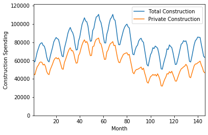

```python
x = df_con.Month
y = df_con['Total Construction']
y1 = df_con['Private Construction']
plt.plot(x,y,label='Total Construction') # The label parameter is a label for the y axis data that will be used in the legend
plt.plot(x,y1,label='Private Construction')
plt.xlabel('Month')                      # Title for the horizontal axis
plt.ylabel('Construction Spending')      # Title for the vertical axis
plt.axis([x.min(),x.max(),0,1.1*y.max()])
plt.legend()
plt.savefig('sample.jpg')
```

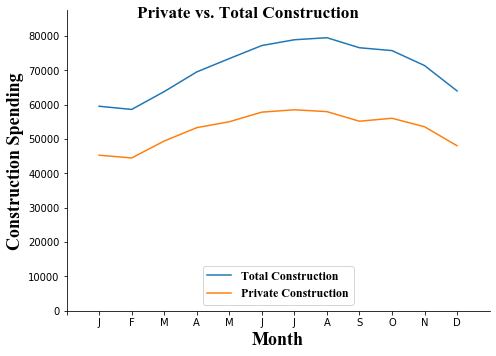

```python
# Extract data for graphing
x = df_con.Month[0:12]
y1 = df_con['Total Construction'][0:12]
y2 = df_con['Private Construction'][0:12]

# My variables
x_labels = ['','J','F','M','A','M','J','J','A','S','O','N','D']

# Create graph and assign Figure and Axes objects to variables fig and ax
fig, ax = plt.subplots()

# Plot the data and set other Axes attributes
ax.plot(x,y1,label='Total Construction')                                  # Add y1 data to graph and create label for the legend
ax.plot(x,y2,label='Private Construction')                                # Add y2 data to graph and create label for the legend
ax.spines['right'].set_visible(False)                                                 # Remove right spine
ax.spines['top'].set_visible(False)    # Remove top spine
ax.legend(loc = 'lower center', prop = {'family':'Times New Roman', 'size':'large'})   # Add legend and format it
ax.set_xlim(0,x.max()+1)                                                              # Set min and max for y axis
ax.set_ylim(0,1.1*y1.max())                                                           # Set min and max for y axis

# Set x-axis attributes
ax.xaxis.set_label_text('Month',fontsize = 18, fontname = 'Times New Roman')
ax.xaxis.set_ticks(range(0,13))
ax.xaxis.set_ticklabels(x_labels)
ax.xaxis.set_tick_params(which = 'both', top = False, bottom = True, labelbottom = True)  # Turn tick marks off for top x axis

# Set y-axis attributes: the parameter 'both' refers to both major and minor tick marks
ax.yaxis.set_label_text('Construction Spending',fontsize = 18, fontname = 'Times New Roman')      # Title for the vertical axis
ax.yaxis.set_tick_params(which = 'both', right = False, left = True, labelleft = True)   # Turn tick marks off for right y axis

# Set Figure attributes
fig.set_size_inches(7,5)             # Set size of figure
fig.suptitle('Private vs. Total Construction',fontsize='xx-large', fontname = 'Times New Roman')
fig.tight_layout()                   # Helps with formatting and fitting everything into the figure
plt.savefig('sample3.jpg')           # Save jpg of figure
```

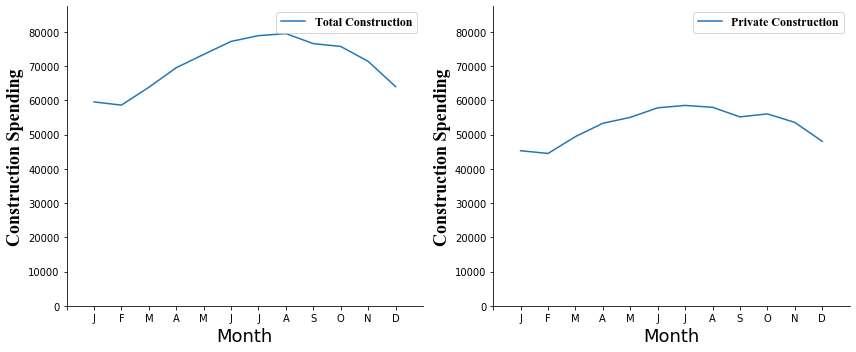

```python
# Extract data for graphing
x = df_con.Month[0:12]
y1 = df_con['Total Construction'][0:12]
y2 = df_con['Private Construction'][0:12]

# My variables
x_labels = ['','J','F','M','A','M','J','J','A','S','O','N','D']

# Create graph and assign Figure and Axes objects to variables fig and Axes variables ax1 and ax2
fig, (ax1, ax2) = plt.subplots(1,2,sharey=True)  # Create 2 Axes (subplots) and assign to ax1 and ax2 respectively

# Plot the data and set other Axes attributes
ax1.plot(x,y1,label='Total Construction')                                  # Add y1 data to graph and create label for the legend
ax2.plot(x,y2,label='Private Construction')                                # Add y2 data to graph and create label for the legend

# Set common axes attributes
for ax in fig.axes:
    ax.spines['right'].set_visible(False)                                                 # Remove right spine
    ax.spines['top'].set_visible(False)                                                   # Remove top spine
    ax.legend(loc = 'upper right', prop = {'family':'Times New Roman', 'size':'large'})   # Add legend and format it
    ax.set_xlim(0,x.max()+1)                                                              # Set min and max for y axis
    ax.set_ylim(0,1.1*y1.max())                                                           # Set min and max for y axis

# Set x-axis attributes
for ax in fig.axes:
    ax.xaxis.set_label_text('Month',fontsize = 18)
    ax.xaxis.set_ticks(range(0,13))
    ax.xaxis.set_ticklabels(x_labels)
    ax.xaxis.set_tick_params(which = 'both', top = False, bottom = True, labelbottom = True)  # Turn top x axis tick marks off

# Set y-axis attributes: the parameter 'both' refers to both major and minor tick marks
for ax in fig.axes:
    ax.yaxis.set_label_text('Construction Spending',fontsize = 18, fontname = 'Times New Roman')    # Title for the vertical axis
    ax.yaxis.set_tick_params(which = 'both', right = False, left = True, labelleft = True)   # Turn right y axis tick marks off

# Set Figure attributes
fig.set_size_inches(12,5)           # Set size of figure
fig.tight_layout()                   # Helps with formatting and fitting everything into the figure
plt.savefig('sample3.jpg')
plt.show()
```

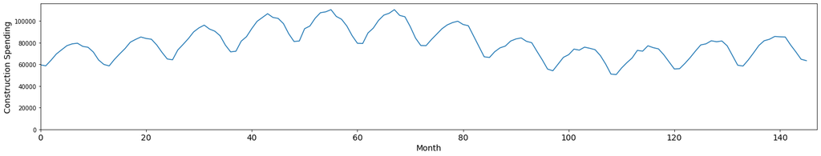

```python
x = df_con.index
y = df_con['Total Construction']
plt.figure(figsize=(24,4))               # figure must be resized prior to .plot() statement
plt.plot(x,y,label='Total Construction')
plt.xlabel('Month',fontsize=14)                      # Title for the horizontal axis
plt.ylabel('Construction Spending',fontsize=14)      # Title for the vertical axis
plt.axis([0,max(df_con['Month'])+1,0,max(df_con['Total Construction'])*1.05],fontsize=14)    # Set ranges of axes
plt.xticks(fontsize = 14)
plt.show()
```

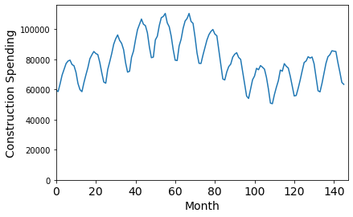

```python
x = df_con.index
y = df_con['Total Construction']
plt.figure(figsize=(6.5,4))               # figure must be resized prior to .plot() statement
plt.plot(x,y,label='Total Construction')
plt.xlabel('Month',fontsize=14)                      # Title for the horizontal axis
plt.ylabel('Construction Spending',fontsize=14)      # Title for the vertical axis
plt.axis([0,max(df_con['Month'])+1,0,max(df_con['Total Construction'])*1.05],fontsize=14)    # Set ranges of axes
plt.xticks(fontsize = 14)
plt.show()
```

# The seaborn Package

seaborn is written 'on top of' matplotlib and automates many forms of multi-graph figures. Here's is one example where each one-to-one relationships in the four fields in the ozone data are shown via a grid of scatter plots. seaborn in this way takes care of a lot of detailed work that you would need to do if you used matplotlib to construct this graph.

```python
import seaborn as sns
```

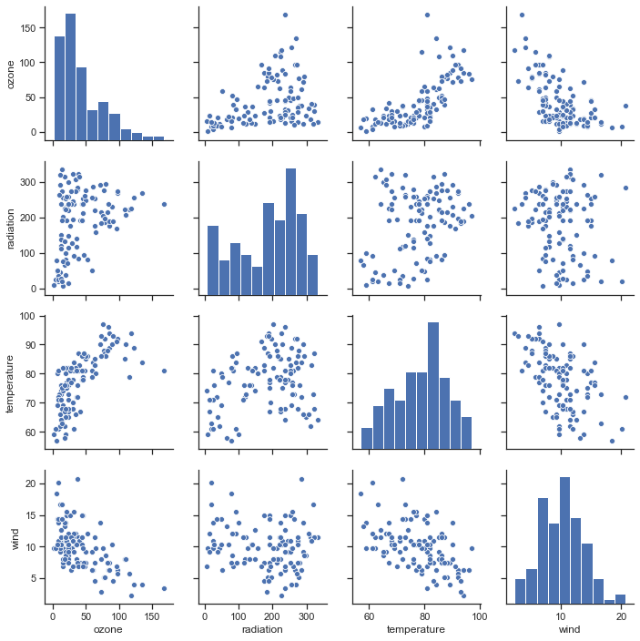

```python
sns.set(style="ticks", color_codes=True)
g = sns.pairplot(df_oz)
g.savefig('ozone.jpg')
```

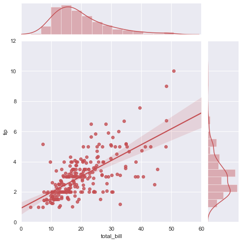

```python
sns.set(style="whitegrid")

xs = [0,82.0442626658045,164.140532825633,249.101916493353,332.182520454561,416.254670963008,495.330844802651,575.152803567278,653.205144040749,738.002602107511,818.027625347191,898.118246791891,980.079475188722,1061.14169245002,1139.27372549306,1222.46124841828,1300.35875796241,1375.56916894815,1450.58381247379,1528.61926864683,1605.58397275636,1690.73526419816,1765.8607155748,1844.76374052086,1927.68455634244,2007.86892722346,2086.83606915306,2166.71913598734,2251.80135023691,2335.70816516882,2420.79263834332,2499.86354911873,2577.05890165442,2654.19208140119,2730.09283946298,2809.07577275313,2894.08624312766,2969.05670691318,3049.93958564477,3129.75861740531,3206.68277248806,3283.60346903165,3364.58552562287,3449.40362446521,3525.4406380069,3608.13685182861,3690.05929028829,3773.14656467608,3850.22786804579,3930.30737684189,4015.46434790825,4093.50879464788,4172.64841837878,4252.66450124259,4335.57956650011,4420.52164467734,4495.52991250898,4575.39742270308,4650.49642074232,4730.52574677055,4805.68851119975,4880.60019974235,4960.70865715944,5043.67168991259,5118.73724644963,5203.54753389807,5283.38430140739,5359.51383129058,5438.3504224767,5519.19106748314,5597.38879699402]
ys = [69,70.5331166725557,71.5580608629997,71.7925736363559,71.3468902075964,70.8280365103217,70.6414982437025,70.4451053764375,70.3795952412711,69.7645648576213,69.5426154537094,69.3004779067882,68.9026747371149,68.599154906399,68.519069857217,68.3772433121902,69.1486631584102,68.7548264957532,68.3609585242701,68.5575021969504,68.5786288310157,70.1801398605569,69.7914710297875,70.1491959166127,71.3308639026079,71.9361568322099,71.7841530239482,71.5632100706621,70.9532872882161,70.4120650812618,69.7956890967353,69.6193830861858,69.6154149236862,69.6130427165012,69.7102463368457,69.5264209638887,68.9050613087613,69.1051712486311,68.8193037564598,68.6066819000086,68.6092749335593,68.6204785117934,68.3360360051156,68.5812312774717,68.3713770000006,69.5440095449469,70.5260768620176,72.0285425812187,72.0349254824144,71.8158332177273,71.1892654017154,71.1169346409977,70.8948191898231,70.6895661675202,70.2298913978404,69.6255849641529,69.7340391269025,69.5070018796742,69.6617353391113,69.4627544694931,69.630774569752,69.8026157834872,69.5269217792645,69.0549816241028,69.1984712324886,68.3562401007611,68.1422906748129,68.2062726166005,68.0498033914326,68.6018257745021,68.7606159741864]


#import seaborn as sns
sns.set(style="darkgrid", color_codes=True)

tips = sns.load_dataset("tips")
g = sns.jointplot("total_bill", "tip", data=tips, kind="reg",
                  xlim=(0, 60), ylim=(0, 12), color="r", size=7)
```

```python
import matplotlib as mpl
import importlib
importlib.reload(mpl); importlib.reload(plt); importlib.reload(sns)
```

```
<module 'seaborn' from 'C:\\Users\\xluo0\\Anaconda3\\lib\\site-packages\\seaborn\\__init__.py'>
```

```python
sns.set_style("whitegrid")
```